# Tugas 2 Praktikum

Intan Aisa M0401241059

2026-09-01

```r
library(lmtest)
library(orcutt)
library(ggplot2)
library (dplyr)
library(readxl)
library(HoRM)
```

# No 1: Analisis Market Share vs Price

## 1.1 Impor dan Praproses Data

Langkah pertama adalah membaca data `data_market_share_price.xlsx`, membuang peubah `Period`, serta me-rename peubah `Market share` menjadi $Y$ (respon) dan `Price` menjadi $X$ (penjelas).

```r
df1 <- read_excel("/Users/intanaisa/Documents/Kuliah/Semester 5/Metode Peramalan Deret Waktu/Praktikum/Praktikum 2/data_market_share_price.xlsx")
df1
```

```
## # A tibble: 20 × 3
##    Period `Market share` Price
##     <dbl>          <dbl> <dbl>
##  1      1           3.63  0.97
##  2      2           4.2   0.95
##  3      3           3.33  0.99
##  4      4           4.54  0.91
##  5      5           2.89  0.98
##  6      6           4.87  0.9
##  7      7           4.9   0.89
##  8      8           5.29  0.86
##  9      9           6.18  0.85
## 10     10           7.2   0.82
## 11     11           7.25  0.79
## 12     12           6.09  0.83
## 13     13           6.8   0.81
## 14     14           8.65  0.77
## 15     15           8.43  0.76
## 16     16           8.29  0.8
## 17     17           7.18  0.83
## 18     18           7.9   0.79
## 19     19           8.45  0.76
## 20     20           8.23  0.78
```

```r
data1 <- df1 %>%
  select(-Period) %>%
  rename(Y = `Market share`,
         X = Price)
```

## 1.2 Pemodelan Awal (OLS)

Model regresi linear awal dibentuk dengan fungsi `lm()`.

```r
model_awal1 <- lm(Y ~ X, data = data1)
summary(model_awal1)
```

```
##
## Call:
## lm(formula = Y ~ X, data = data1)
##
## Residuals:
##      Min       1Q   Median       3Q      Max
## -0.73068 -0.29764 -0.00966  0.30224  0.81193
##
## Coefficients:
##             Estimate Std. Error t value Pr(>|t|)
## (Intercept)   26.910      1.110   24.25 3.39e-15 ***
## X            -24.290      1.298  -18.72 3.02e-13 ***
## ---
## Signif. codes:  0 '***' 0.001 '**' 0.01 '*' 0.05 '.' 0.1 ' ' 1
##
## Residual standard error: 0.4287 on 18 degrees of freedom
## Multiple R-squared:  0.9511, Adjusted R-squared:  0.9484
## F-statistic: 350.3 on 1 and 18 DF,  p-value: 3.019e-13
```

Berdasarkan hasil pemodelan awal OLS, peubah harga ($X$) terbukti berpengaruh negatif dan signifikan secara statistik terhadap pangsa pasar ($Y$) dengan nilai $p\text{-value} < 0.05$. Hasil uji F juga menunjukkan bahwa model regresi ini layak digunakan secara simultan. Selain itu, nilai Adjusted R-squared sebesar $0.9484$ mengindikasikan bahwa $94.84\%$ keragaman pangsa pasar mampu dijelaskan oleh peubah harga, sementara sisanya dipengaruhi oleh faktor lain di luar model.

## 1.3 Uji Asumsi Sisaan Secara Eksploratif

Sebelum melakukan inferensi lebih jauh, dilakukan uji diagnostik sisaan menggunakan 4 plot utama: Q-Q Plot Normal, Sisaan vs Fitted Values, Histogram Sisaan, dan Sisaan vs Order (Waktu).

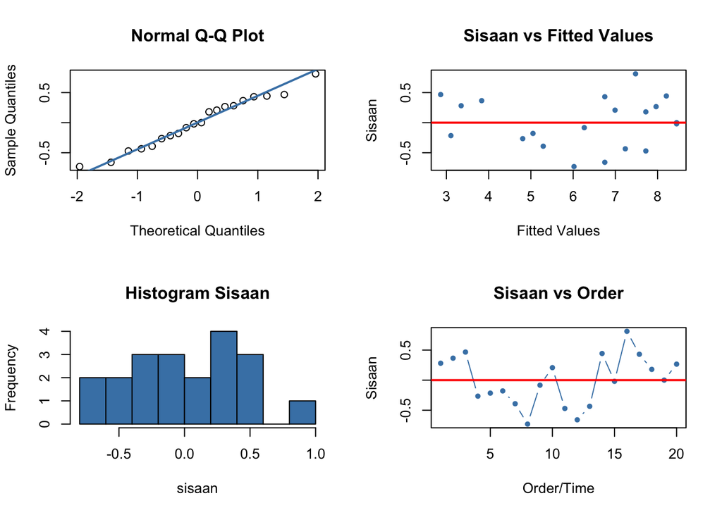

```r
#sisaan dan fitted value
sisaan <- residuals(model_awal1)
fitValue <- predict(model_awal1)
n <- length(sisaan)

par(mfrow = c(2,2))
qqnorm(sisaan)
qqline(sisaan, col = "steelblue", lwd = 2)

plot(fitValue, sisaan, col = "steelblue", pch = 20, xlab = "Fitted Values", ylab = "Sisaan", main = "Sisaan vs Fitted Values")
abline(h = 0, col = "red", lwd = 2)

hist(sisaan, col = "steelblue", main = "Histogram Sisaan")

# Sumbu X menggunakan 1:n agar sesuai dengan panjang data sisaan
plot(1:n, sisaan, col = "steelblue", pch = 20, type = "b", xlab = "Order/Time", ylab = "Sisaan", main = "Sisaan vs Order")
abline(h = 0, col = "red", lwd = 2)
```

```r
par(mfrow = c(1,1))
```

Berdasarkan plot diagnostik eksploratif, sebaran titik-titik pada Normal Q-Q Plot yang menempel rapat pada garis diagonal serta bentuk Histogram Sisaan yang relatif simetris mengindikasikan bahwa sisaan berdistribusi normal. Pada plot Sisaan vs Fitted Values, titik-titik menyebar secara acak di sekitar garis nol tanpa membentuk pola tertentu, yang menandakan terpenuhinya asumsi kehomogenan ragam (homoskedastisitas). Namun, pada plot Sisaan vs Order terlihat adanya pergerakan menyatu dan gelombang beruntun sepanjang waktu ($t=1$ hingga $t=20$), yang menjadi indikasi awal hadirnya masalah autokorelasi positif pada sisaan.

## 1.4 Uji Asumsi Sisaan secara Formal

### A. Uji Normalitas (Shapiro-Wilk)

$H_0$: Sisaan menyebar normal

$H_1$: Sisaan tidak menyebar normal

```r
shapiro.test(residuals(model_awal1))
```

```
##
##  Shapiro-Wilk normality test
##
## data:  residuals(model_awal1)
## W = 0.9744, p-value = 0.8437
```

Nilai $p\text{-value} > 0.05$, sehingga $H_0$ tidak ditolak, artinya asumsi normalitas sisaan terpenuhi.

### B. Uji Homoskedastisitas (Breusch-Pagan)

$H_0$: Ragam sisaan homogen

$H_1$: Ragam tidak sisaan homogen

```r
bptest(model_awal1)
```

```
##
##  studentized Breusch-Pagan test
##
## data:  model_awal1
## BP = 0.11646, df = 1, p-value = 0.7329
```

Nilai $p\text{-value} > 0.05$, sehingga $H_0$ tidak ditolak, artinya asumsi kehomogenan ragam sisaan terpenuhi.

### C. Uji Autokorelasi (Durbin-Watson)

$H_0$: Tidak ada autokorelasi positif pada sisaan ($\rho = 0$)

$H_1$: Ada autokorelasi positif pada sisaan ($\rho > 0$)

```r
dwtest(model_awal1)
```

```
##
##  Durbin-Watson test
##
## data:  model_awal1
## DW = 1.1358, p-value = 0.009813
## alternative hypothesis: true autocorrelation is greater than 0
```

Nilai $p\text{-value} < 0.05$, sehingga $H_0$ ditolak. Hal ini membuktikan bahwa terdapat autokorelasi pada sisaan model OLS awal. Oleh karena itu, diperlukan penanganan autokorelasi.

## 1.5 Penanganan Autokorelasi

### Metode 1: Cochrane-Orcutt

Metode Cochrane-Orcutt melakukan iterasi untuk mengestimasi nilai $\rho$ dan memutakhirkan parameter regresi melalui transformasi perbedaan terbobot (*weighted diferencing*).

```r
model_orcutt1 <- cochrane.orcutt(model_awal1)
summary(model_orcutt1)
```

```
## Call:
## lm(formula = Y ~ X, data = data1)
##
##             Estimate Std. Error t value  Pr(>|t|)
## (Intercept)  26.7221     1.6329  16.365 7.713e-12 ***
## X           -24.0841     1.9385 -12.424 5.903e-10 ***
## ---
## Signif. codes:  0 '***' 0.001 '**' 0.01 '*' 0.05 '.' 0.1 ' ' 1
##
## Residual standard error: 0.3955 on 17 degrees of freedom
## Multiple R-squared:  0.9008 ,  Adjusted R-squared:  0.895
## F-statistic: 154.4 on 1 and 17 DF,  p-value: < 5.903e-10
##
## Durbin-Watson statistic
## (original):    1.13582 , p-value: 9.813e-03
## (transformed): 1.95804 , p-value: 4.151e-01
```

Selanjutnya, lakukan uji Durbin-Watson kembali pada model Cochrane-Orcutt untuk memastikan autokorelasi telah teratasi

```r
dwtest(model_orcutt1)
```

```
##
##  Durbin-Watson test
##
## data:  model_orcutt1
## DW = 1.958, p-value = 0.4151
## alternative hypothesis: true autocorrelation is greater than 0
```

Setelah ditangani dengan Cochrane-Orcutt, statistik Durbin-Watson mendakati nilai 2 dan nilai $p$-value $> 0.05$. Ini menunjukkan bahwa autokorelasi telah berhasil diatasi.

### Metode 2: Hildreth-Lu

Metode Hildreth-Lu mencari nilai $\rho$ optimum dalam selang $(-1, 1)$ yang meminimumkan nilai Sum of Squared Errors (SSE).

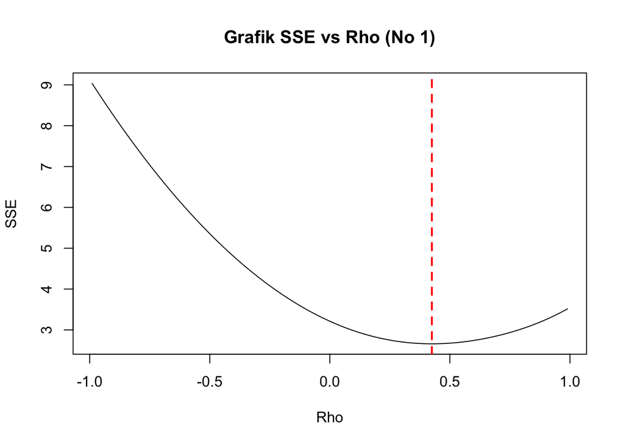

```r
hildreth.lu.func <- function(r, model){
  x <- model.matrix(model)[,-1]
  y <- model.response(model.frame(model))
  n <- length(y)
  t <- 2:n
  y_star <- y[t] - r * y[t-1]
  x_star <- x[t] - r * x[t-1]
  return(lm(y_star ~ x_star))
}

r1 <- seq(-0.99, 0.99, by = 0.01)
tab1 <- data.frame(
  "rho" = r1,
  "SSE" = sapply(r1, function(i){ deviance(hildreth.lu.func(i, model_awal1)) })
)

rho_kasar1 <- tab1$rho[which.min(tab1$SSE)]

rOpt1 <- seq(rho_kasar1 - 0.05, rho_kasar1 + 0.05, by = 0.001)
tabOpt1 <- data.frame(
  "rho" = rOpt1,
  "SSE" = sapply(rOpt1, function(i){ deviance(hildreth.lu.func(i, model_awal1)) })
)

plot(tab1$SSE ~ tab1$rho, type = "l", xlab = "Rho", ylab = "SSE", main = "Grafik SSE vs Rho (No 1)")
rho_opt1 <- tabOpt1$rho[which.min(tabOpt1$SSE)]
abline(v = rho_opt1, col = "red", lty = 2, lwd = 2)
```

```r
rho_opt1
```

```
## [1] 0.425
```

Nilai $\rho$ Optimum Hildreth-Lu: Nilai $\rho$ yang meminimumkan SSE adalah 0.425.

Selanjutnya bentuk model Hildreth-Lu menggunakan $\rho$ optimum tersebut dan mengecek uji Durbin-Watson:

```r
modelHL1 <- hildreth.lu.func(rho_opt1, model_awal1)
summary(modelHL1)
```

```
##
## Call:
## lm(formula = y_star ~ x_star)
##
## Residuals:
##      Min       1Q   Median       3Q      Max
## -0.55517 -0.25066 -0.05505  0.25010  0.83017
##
## Coefficients:
##             Estimate Std. Error t value Pr(>|t|)
## (Intercept)  15.3655     0.9387   16.37 7.68e-12 ***
## x_star      -24.0848     1.9380  -12.43 5.88e-10 ***
## ---
## Signif. codes:  0 '***' 0.001 '**' 0.01 '*' 0.05 '.' 0.1 ' ' 1
##
## Residual standard error: 0.3955 on 17 degrees of freedom
## Multiple R-squared:  0.9008, Adjusted R-squared:  0.895
## F-statistic: 154.4 on 1 and 17 DF,  p-value: 5.88e-10
```

```r
dwtest(modelHL1)
```

```
##
##  Durbin-Watson test
##
## data:  modelHL1
## DW = 1.9577, p-value = 0.4148
## alternative hypothesis: true autocorrelation is greater than 0
```

Nilai $p$-value dari Uji Durbin-Watson $> 0.05$, mengindikasikan bahwa model Hildreth-Lu juga berhasil menghilangkan masalah autokorelasi.

## 1.6 Kesimpulan

1. Model awal OLS mengalami masalah autokorelasi ($p$-value DW $< 0.05$), meskipun asumsi normalitas dan homoskedastisitas terpenuhi.
2. Penanganan menggunakan metode Cochrane-Orcutt maupun Hildreth-Lu terbukti efektif membebaskan model dari autokorelasi ($p$-value DW $> 0.05$).
3. Model akhir yang bebas dari autokorelasi dapat digunakan untuk keperluan pendugaan dan peramalan Market Share berdasarkan Price secara lebih valid karena standar erornya tidak lagi underestimated.

# Nomor 2: Analisis Sales vs Advertising (1975-2014)

## 2.1 Impor dan Praproses Data

Pada studi kasus kedua, dilakukan analisis pengaruh biaya iklan (Advertising) terhadap tingkat penjualan (Sales) periode 1975–2014.

```r
df2 <- read_excel("/Users/intanaisa/Documents/Kuliah/Semester 5/Metode Peramalan Deret Waktu/Praktikum/Praktikum 2/data_sales_advertising_1975_2014.xlsx")
df2
```

```
## # A tibble: 40 × 3
##     Year Sales Advertising
##    <dbl> <dbl>       <dbl>
##  1  1975  11.7         9.4
##  2  1976  12           9.6
##  3  1977  12.3        10
##  4  1978  12.8        10.4
##  5  1979  13.1        10.8
##  6  1980  13.6        10.9
##  7  1981  13.9        11.7
##  8  1982  14.4        12.2
##  9  1983  14.7        12.5
## 10  1984  15.3        12.9
## # ℹ 30 more rows
```

```r
data2 <- df2 %>%
  select(-Year) %>%
  rename(Y = Sales,
         X = Advertising)
```

## 2.2 Pemodelan Awal (OLS)

```r
model_awal2 <- lm(Y ~ X, data = data2)
summary(model_awal2)
```

```
##
## Call:
## lm(formula = Y ~ X, data = data2)
##
## Residuals:
##      Min       1Q   Median       3Q      Max
## -1.03758 -0.40343  0.08933  0.45674  0.74036
##
## Coefficients:
##             Estimate Std. Error t value Pr(>|t|)
## (Intercept)  5.96513    0.38092   15.66   <2e-16 ***
## X            0.71035    0.02365   30.04   <2e-16 ***
## ---
## Signif. codes:  0 '***' 0.001 '**' 0.01 '*' 0.05 '.' 0.1 ' ' 1
##
## Residual standard error: 0.527 on 38 degrees of freedom
## Multiple R-squared:  0.9596, Adjusted R-squared:  0.9585
## F-statistic: 902.3 on 1 and 38 DF,  p-value: < 2.2e-16
```

Berdasarkan hasil pemodelan awal OLS, peubah biaya iklan ($X$) terbukti berpengaruh positif dan sangat signifikan secara statistik terhadap tingkat penjualan ($Y$) dengan nilai $p\text{-value} < 2 \times 10^{-16}$. Hasil uji F dengan statistik $902.3$ juga mengonfirmasi bahwa model regresi ini sangat layak secara simultan. Selain itu, nilai Adjusted R-squared sebesar $0.9585$ menunjukkan bahwa sebesar $95.85\%$ keragaman penjualan mampu dijelaskan oleh biaya iklan, sedangkan sisanya dipengaruhi oleh variabel lain di luar model.

## 2.3 Uji Asumsi Sisaan Secara Eksploratif

Sebelum melangkah ke uji formal, dilakukan pemeriksaan asumsi sisaan secara eksploratif menggunakan empat plot diagnostik.

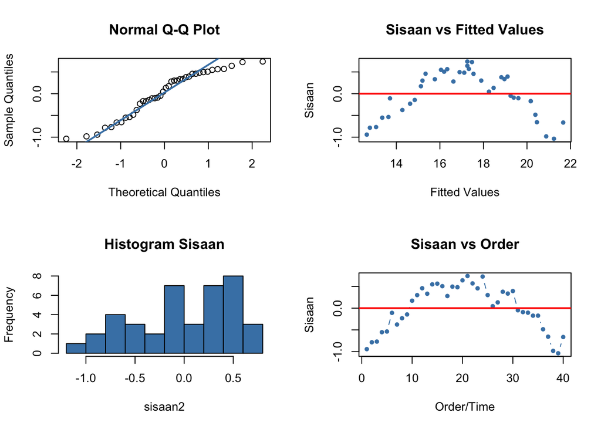

```r
sisaan2 <- residuals(model_awal2)
fitValue2 <- predict(model_awal2)
n2 <- length(sisaan2)

par(mfrow = c(2,2))
qqnorm(sisaan2)
qqline(sisaan2, col = "steelblue", lwd = 2)

plot(fitValue2, sisaan2, col = "steelblue", pch = 20, xlab = "Fitted Values", ylab = "Sisaan", main = "Sisaan vs Fitted Values")
abline(h = 0, col = "red", lwd = 2)

hist(sisaan2, col = "steelblue", main = "Histogram Sisaan")

plot(1:n2, sisaan2, col = "steelblue", pch = 20, type = "b", xlab = "Order/Time", ylab = "Sisaan", main = "Sisaan vs Order")
abline(h = 0, col = "red", lwd = 2)
```

```r
par(mfrow = c(1,1))
```

## Uji Asumsi Sisaan Secara Formal

### A. Uji Normalitas (Shapiro-Wilk)

```r
shapiro.test(residuals(model_awal2))
```

```
##
##  Shapiro-Wilk normality test
##
## data:  residuals(model_awal2)
## W = 0.93205, p-value = 0.0188
```

$p$-value $< 0.05$, maka sisaan tidak berdistribusi normal.

### B. Uji Homoskedastisitas (Breusch-Pagan)

```r
bptest(model_awal2)
```

```
##
##  studentized Breusch-Pagan test
##
## data:  model_awal2
## BP = 0.0037386, df = 1, p-value = 0.9512
```

$p$-value $> 0.05$, maka ragam sisaan homogen (homoskedastisitas terpenuhi).

### C. Uji Autokorelasi (Durbin-Watson)

```r
dwtest(model_awal2)
```

```
##
##  Durbin-Watson test
##
## data:  model_awal2
## DW = 0.16204, p-value < 2.2e-16
## alternative hypothesis: true autocorrelation is greater than 0
```

Nilai $p$-value $< 0.05$, yang berarti $H_0$ ditolak. Terbukti secara formal bahwa terdapat autokorelasi pada model OLS awal.

## 2.5 Penanganan Autokorelasi

### Metode 1: Cochrane-Orcutt

```r
model_orcutt2 <- cochrane.orcutt(model_awal2)
summary(model_orcutt2)
```

```
## Call:
## lm(formula = Y ~ X, data = data2)
##
##              Estimate Std. Error t value  Pr(>|t|)
## (Intercept) 10.252375   1.459736   7.023 2.638e-08 ***
## X            0.488489   0.075426   6.476 1.426e-07 ***
## ---
## Signif. codes:  0 '***' 0.001 '**' 0.01 '*' 0.05 '.' 0.1 ' ' 1
##
## Residual standard error: 0.1868 on 37 degrees of freedom
## Multiple R-squared:  0.5313 ,  Adjusted R-squared:  0.5186
## F-statistic: 41.9 on 1 and 37 DF,  p-value: < 1.426e-07
##
## Durbin-Watson statistic
## (original):    0.16204 , p-value: 8.935e-20
## (transformed): 1.93925 , p-value: 3.78e-01
```

Uji ulang Durbin-Watson setelah penanganan Cochrane-Orcutt:

```r
dwtest(model_orcutt2)
```

```
##
##  Durbin-Watson test
##
## data:  model_orcutt2
## DW = 1.9393, p-value = 0.378
## alternative hypothesis: true autocorrelation is greater than 0
```

$p$-value Uji DW $> 0.05$. Masalah autokorelasi telah berhasil diatasi menggunakan transformasi Cochrane-Orcutt.

### Metode 2: Hildreth-Lu

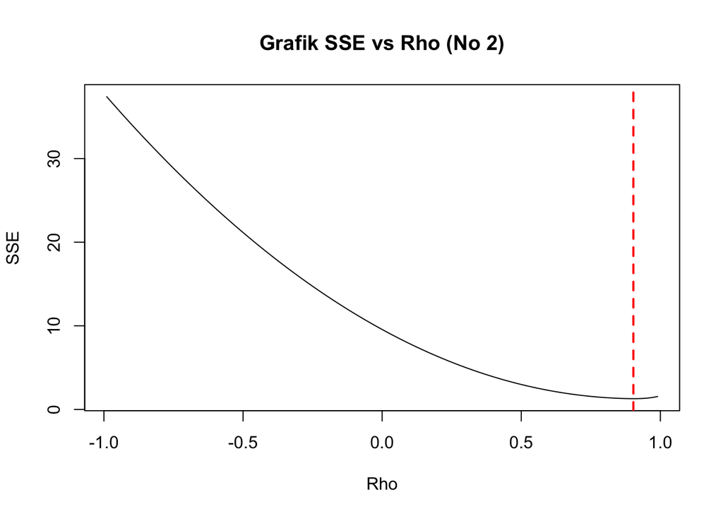

```r
hildreth.lu.func <- function(r, model){
  x <- model.matrix(model)[,-1]
  y <- model.response(model.frame(model))
  n <- length(y)
  t <- 2:n
  y_star <- y[t] - r * y[t-1]
  x_star <- x[t] - r * x[t-1]
  return(lm(y_star ~ x_star))
}

r2 <- seq(-0.99, 0.99, by = 0.01)
tab2 <- data.frame(
  "rho" = r2,
  "SSE" = sapply(r2, function(i){ deviance(hildreth.lu.func(i, model_awal2)) })
)

rho_kasar2 <- tab2$rho[which.min(tab2$SSE)]

rOpt2 <- seq(rho_kasar2 - 0.05, rho_kasar2 + 0.05, by = 0.001)
tabOpt2 <- data.frame(
  "rho" = rOpt2,
  "SSE" = sapply(rOpt2, function(i){ deviance(hildreth.lu.func(i, model_awal2)) })
)

plot(tab2$SSE ~ tab2$rho, type = "l", xlab = "Rho", ylab = "SSE", main = "Grafik SSE vs Rho (No 2)")
rho_opt2 <- tabOpt2$rho[which.min(tabOpt2$SSE)]
abline(v = rho_opt2, col = "red", lty = 2, lwd = 2)
```

```r
rho_opt2
```

```
## [1] 0.903
```

Nilai $\rho$ Optimum Hildreth-Lu: Nilai $\rho$ terbaik adalah 0.903.

Estimasi model akhir Hildreth-Lu dan cek Durbin-Watson:

```r
modelHL2 <- hildreth.lu.func(rho_opt2, model_awal2)
summary(modelHL2)
```

```
##
## Call:
## lm(formula = y_star ~ x_star)
##
## Residuals:
##      Min       1Q   Median       3Q      Max
## -0.37720 -0.14949  0.01266  0.10464  0.45301
##
## Coefficients:
##             Estimate Std. Error t value Pr(>|t|)
## (Intercept)  0.99401    0.14144   7.028 2.60e-08 ***
## x_star       0.48869    0.07536   6.485 1.39e-07 ***
## ---
## Signif. codes:  0 '***' 0.001 '**' 0.01 '*' 0.05 '.' 0.1 ' ' 1
##
## Residual standard error: 0.1868 on 37 degrees of freedom
## Multiple R-squared:  0.532,  Adjusted R-squared:  0.5193
## F-statistic: 42.05 on 1 and 37 DF,  p-value: 1.39e-07
```

```r
dwtest(modelHL2)
```

```
##
##  Durbin-Watson test
##
## data:  modelHL2
## DW = 1.9393, p-value = 0.378
## alternative hypothesis: true autocorrelation is greater than 0
```

Nilai $p$-value Uji DW $> 0.05$, mengindikasikan metode Hildreth-Lu juga sukses menghilangkan autokorelasi.